# Wrangling The Simpsons

Maeva Assi

2025-04-11

# Introduction & Setup

In this simple andinteractive data wrangling tutorial, you will learn how to:

- use `filter()` and `arrange()` to manipulate rows;
- use `select()`, `mutate()` and `summarize()` to manipulate and create columns;
- use `join()` to join tables together;
- use `ggplot()`to visualize data.

We will use the [Simpson Dataset from Kaggle](https://www.kaggle.com/datasets/prashant111/the-simpsons-dataset/data) which is composed of `simpsons_characters`, `simpsons_episodes` and `simpsons_script_lines`, respectively containing character details, episode details, and script lines for approximately 600 Simpsons episodes. It was originally pulled by Tod Schenider in 2016 and uploaded by William Cukierski.

By the end of the tutorial, you’ll be able to comment on:  
- which season of the Simpsons has the highest IMDb rating;  
- how has the IMDb ratings changed over the seasons;  
- which character has the most spoken lines across all episodes;  
- whether there is a relationship between word count and IMDb rating?

*Please note that episodes and script lines have been filtered to only include episodes from 2010 to 2016.*  
*Click [here](https://github.com/rfordatascience/tidytuesday/blob/main/data/2025/2025-02-04/readme.md) for a Github link to the data.*

## Setup

I’ve already loaded the data for you, but let’s load the tidyverse and ggplot2 packages together.

```r
#Load packages
library(tidyverse)
library(ggplot2)
```

# I. Manipulating rows

First, let’s look at the `simpsons_characters` data. It has the following variables:

- id: unique identifier for each character record.
- name: full name associated with the character record.
- normalized_name: lowercase version of the character name.
- gender: gender associated with the character record (“f”, “m”, or NA).

Take a look at the data before we manipulate it:

```r
simpsons_characters
```

```
## # A tibble: 6,722 × 4
##       id name             normalized_name  gender
##    <dbl> <chr>            <chr>            <chr>
##  1     7 Children         children         <NA>
##  2    12 Mechanical Santa mechanical santa <NA>
##  3    13 Tattoo Man       tattoo man       <NA>
##  4    16 DOCTOR ZITSOFSKY doctor zitsofsky <NA>
##  5    20 Students         students         <NA>
##  6    24 Little Boy       little boy       <NA>
##  7    26 Lewis Clark      lewis clark      <NA>
##  8    27 Little Girl      little girl      <NA>
##  9    29 Bubbles          bubbles          <NA>
## 10    30 Moldy            moldy            <NA>
## # … with 6,712 more rows
```

The row count indicates that there are 6,722 characters reported on The Simpsons.

## a. filter()

Many characters do not have a reported gender, sometimes because they’re minor characters or one entry represents a group of people (“Students”, or “Children” for example).

Let’s try to find out how many characters were reported as **female**.  
The verb `filter()` extracts specific rows from a data frame that meet one or multiple logical criterion.  
To filter for the criteria of interest, you use the **“==” logical operator**, which means “is equal to”. For example, to filter the gender for female characters only, you’d write:

```r
simpsons_characters |>
  filter(gender == "f")
```

```
## # A tibble: 71 × 4
##       id name                    normalized_name         gender
##    <dbl> <chr>                   <chr>                   <chr>
##  1     1 Marge Simpson           marge simpson           f
##  2     9 Lisa Simpson            lisa simpson            f
##  3    40 Edna Krabappel-Flanders edna krabappel-flanders f
##  4    22 Selma Bouvier           selma bouvier           f
##  5    10 Patty Bouvier           patty bouvier           f
##  6    54 Sherri Mackleberry      sherri mackleberry      f
##  7     4 JANEY                   janey                   f
##  8    44 Ms. Melon               ms melon                f
##  9    55 Terri Mackleberry       terri mackleberry       f
## 10    98 Receptionist            receptionist            f
## # … with 61 more rows
```

The row count indicates that there are 71 characters reported on The Simpsons as female.

Your turn! Edit the code to filter for male characters:

```r
#Edit the code
simpsons_characters |>
  filter(...)
```

```r
#Solution
simpsons_characters |>
  filter(gender == "m")
```

```
## # A tibble: 252 × 4
##       id name                normalized_name     gender
##    <dbl> <chr>               <chr>               <chr>
##  1     8 Bart Simpson        bart simpson        m
##  2    17 Moe Szyslak         moe szyslak         m
##  3     3 Seymour Skinner     seymour skinner     m
##  4    11 Ned Flanders        ned flanders        m
##  5    31 Grampa Simpson      grampa simpson      m
##  6    71 Chief Wiggum        chief wiggum        m
##  7    25 Milhouse Van Houten milhouse van houten m
##  8    14 Waylon Smithers     waylon smithers     m
##  9   101 Nelson Muntz        nelson muntz        m
## 10    33 Announcer           announcer           m
## # … with 242 more rows
```

By the way, it is sometimes easier to define what you **don’t** want as your criteria.  
In this case, you use the **“!=” logical operator**, which means “not equal to”.  
If we wanted to filter for characters with a defined gender only (so excluding characters with the gender “NA”):

```r
simpsons_characters |>
  filter(gender != "NA")
```

```
## # A tibble: 323 × 4
##       id name                normalized_name     gender
##    <dbl> <chr>               <chr>               <chr>
##  1     1 Marge Simpson       marge simpson       f
##  2     8 Bart Simpson        bart simpson        m
##  3     9 Lisa Simpson        lisa simpson        f
##  4    17 Moe Szyslak         moe szyslak         m
##  5     3 Seymour Skinner     seymour skinner     m
##  6    11 Ned Flanders        ned flanders        m
##  7    31 Grampa Simpson      grampa simpson      m
##  8    71 Chief Wiggum        chief wiggum        m
##  9    25 Milhouse Van Houten milhouse van houten m
## 10    14 Waylon Smithers     waylon smithers     m
## # … with 313 more rows
```

## b. arrange()

Notice the order of the `id` values. It could be preferable to have the id numbers in ascending order.  
You can use `arrange()` to reorder your rows in ascending (default) or descending order.  
The code to reorder the data by ascending descending order of `id` number is:

```r
simpsons_characters |>
  arrange(id)
```

```
## # A tibble: 6,722 × 4
##       id name            normalized_name gender
##    <dbl> <chr>           <chr>           <chr>
##  1     1 Marge Simpson   marge simpson   f
##  2     2 Homer Simpson   homer simpson   m
##  3     3 Seymour Skinner seymour skinner m
##  4     4 JANEY           janey           f
##  5     5 Todd Flanders   todd flanders   m
##  6     6 Dewey Largo     dewey largo     m
##  7     7 Children        children        <NA>
##  8     8 Bart Simpson    bart simpson    m
##  9     9 Lisa Simpson    lisa simpson    f
## 10    10 Patty Bouvier   patty bouvier   f
## # … with 6,712 more rows
```

*NB: For descending order, you would use `arrange(desc(id))` .*

Your turn! The code below filtered for male characters and arranged the data in ascending order of `id`. Edit the code to filter for female characters and reorder their names in alphabetical order:

```r
#Edit the code
simpsons_characters |>
  filter(gender == "m") |>
  arrange(id)
```

```r
#Solution
simpsons_characters |>
  filter(gender == "f") |>
  arrange(name)
```

```
## # A tibble: 71 × 4
##       id name             normalized_name  gender
##    <dbl> <chr>            <chr>            <chr>
##  1   192 Agnes Skinner    agnes skinner    f
##  2  2553 Alex             alex             f
##  3  1476 Allison          allison          f
##  4  5947 Annie Crawford   annie crawford   f
##  5   533 BARBARA          barbara          f
##  6   645 Becky            becky            f
##  7  2087 Belle            belle            f
##  8  3011 Betty White      betty white      f
##  9  1875 Brandine Del Roy brandine del roy f
## 10  4234 CHLOE            chloe            f
## # … with 61 more rows
```

# II. Manipulating and creating columns

## a. select()

Now let’s look at the `simpsons_episodes` data. It has the following variables:

- id: unique identifier for each episode record.
- image_url: URL linking to the image associated with the episode record.
- imdb_rating: IMDb rating for the episode.
- imdb_votes: number of votes received on IMDb for the episode.
- number_in_season: episode number within the season.
- number_in_series: episode number within the series.
- original_air_date: date the episode originally aired.
- original_air_year: year the episode originally aired.
- production_code: code used in production to identify the episode.
- season: season number of the episode.
- title: title of the episode.
- us_viewers_in_millions: number of viewers in the U.S. in millions.
- video_url: URL linking to the video associated with the record.
- views: total number of views recorded for the episode video URL.

That’s a *lot* of variables to keep track of…  
We’re only interested in the **id, imdb_rating, number_in_season, number_in_series, original_air_year, season, title and us_viewers_in_millions** variables.  
Extracting relevant columns is easy using the verb `select()`. We’re going to save our selection as an object called `simpsons_eps_clean`.

```r
simpsons_eps_clean <- simpsons_episodes |>
  select(
    id,
    imdb_rating,
    number_in_season,
    number_in_series,
    original_air_year,
    season,
    title,
    us_viewers_in_millions)
simpsons_eps_clean
```

```
## # A tibble: 151 × 8
##       id imdb_rating number_in_season number_in_s…¹ origi…² season title us_vi…³
##    <dbl>       <dbl>            <dbl>         <dbl>   <dbl>  <dbl> <chr>   <dbl>
##  1   450         6.8                9           450    2010     21 Thur…    8.65
##  2   452         7.1               11           452    2010     21 Mill…    5.11
##  3   455         7.1               14           455    2010     21 Post…    5.23
##  4   457         5.7               16           457    2010     21 The …    5.69
##  5   462         6.9               21           462    2010     21 Moe …    5.66
##  6   464         6.6               23           464    2010     21 Judg…    5.74
##  7   466         6.8                2           466    2010     22 Loan…    8.59
##  8   469         7.2                5           469    2010     22 Lisa…    8.97
##  9   472         6.9                8           472    2010     22 The …    9.54
## 10   473         7                  9           473    2010     22 Donn…    7.18
## # … with 141 more rows, and abbreviated variable names ¹number_in_series,
## #   ²original_air_year, ³us_viewers_in_millions
```

## b. summarize()

There are 151 episodes. Let’s see how those episodes are divided through seasons.  
To do this, you want to calculate the total number of episodes **by season**. The count is calculated using `n()`.

`summarize()` is useful to create a new table of summary statistics for a group. Let’s call our new variable `total_episode_count` and arrange the data by descending order.

```r
simpsons_eps_clean |>
  summarize(total_episode_count = n(),
            .by = season) |>
  arrange(desc(total_episode_count))
```

```
## # A tibble: 8 × 2
##   season total_episode_count
##    <dbl>               <int>
## 1     22                  22
## 2     23                  22
## 3     24                  22
## 4     25                  22
## 5     26                  22
## 6     27                  22
## 7     21                  15
## 8     28                   4
```

Your turn!  
Let’s find out which season had the best average IMDb rating using `summarize()` .  
Not all episodes of season 28 had ratings, so make sure to filter those out. You want to calculate the **mean imdb_rating by season** using `mean()` and call the resulting variable `avg_imdb_season_rating`.  
Use `arrange()` to reorder your rows in descending order!  
Save your work under a new object `simpsons_seasons`.  
*Don’t forget that `arrange()` sorts by ascending order by default.*

```r
#Edit the code
simpsons_seasons <- simpsons_eps_clean |>
  filter(imdb_rating != "NA") |>
  summarize(avg_imdb_season_rating = mean(...),
            .by = ...) |>
  arrange(...)

simpsons_seasons
```

```r
#Solution
simpsons_seasons <- simpsons_eps_clean |>
  filter(imdb_rating != "NA") |>
  summarize(avg_imdb_season_rating = mean(imdb_rating),
            .by = season) |>
  arrange(desc(avg_imdb_season_rating))

simpsons_seasons
```

```
## # A tibble: 8 × 2
##   season avg_imdb_season_rating
##    <dbl>                  <dbl>
## 1     25                   6.83
## 2     23                   6.81
## 3     21                   6.81
## 4     22                   6.80
## 5     27                   6.79
## 6     24                   6.78
## 7     26                   6.70
## 8     28                   6.6
```

Season 25 is the season with highest average IMDb rating of 6.83!

## c. mutate()

Season 25 has the highest average IMDb rating, but it is not necessarily the season with the highest ratings or highest rated episode.  
We should explore more of the IMDb ratings summary statistics per season, such as the standard deviation (using `sd()`) and the range.  
There’s no direct formula for the range so we’ll use a different function to calculate it “manually” later on.

First, using `summarize()`, we create a new table with the mean, standard deviation, and lowest and highest IMDb ratings:

```r
simpsons_summary <- simpsons_eps_clean |>
  filter(imdb_rating != "NA") |>
  summarize(max_imdb = max(imdb_rating),
            min_imdb = min(imdb_rating),
            avg_imdb_rating = mean(imdb_rating),
            sd_imdb_rating = sd(imdb_rating),
            .by = season)

simpsons_summary
```

```
## # A tibble: 8 × 5
##   season max_imdb min_imdb avg_imdb_rating sd_imdb_rating
##    <dbl>    <dbl>    <dbl>           <dbl>          <dbl>
## 1     21      7.2      5.7            6.81          0.366
## 2     22      7.3      6.1            6.80          0.337
## 3     23      8.2      4.5            6.81          0.747
## 4     24      7.3      6.2            6.78          0.339
## 5     25      7.7      5.8            6.83          0.416
## 6     26      7.9      5.8            6.70          0.472
## 7     27      8.4      5.9            6.79          0.522
## 8     28      6.6      6.6            6.6          NA
```

To calculate the range, we’ll use `mutate()`, a function that lets you create a new column based on other columns.  
The formula for the range would be max_imdb - min_imdb, which we plug in `mutate()`, and we’ll call the resulting column `range_imdb_rating`:

```r
simpsons_summary |>
  mutate(range_imdb_rating = max_imdb - min_imdb) |>
  arrange(desc(range_imdb_rating))
```

```
## # A tibble: 8 × 6
##   season max_imdb min_imdb avg_imdb_rating sd_imdb_rating range_imdb_rating
##    <dbl>    <dbl>    <dbl>           <dbl>          <dbl>             <dbl>
## 1     23      8.2      4.5            6.81          0.747               3.7
## 2     27      8.4      5.9            6.79          0.522               2.5
## 3     26      7.9      5.8            6.70          0.472               2.1
## 4     25      7.7      5.8            6.83          0.416               1.9
## 5     21      7.2      5.7            6.81          0.366               1.5
## 6     22      7.3      6.1            6.80          0.337               1.2
## 7     24      7.3      6.2            6.78          0.339               1.1
## 8     28      6.6      6.6            6.6          NA                   0
```

# III. Joining data

A **join** is a way to combine 2 dataframes based on common columns called keys.  
To find out which character spoke the most words, which season had the most spoken words, and which character spoke the most words per season and whether there is a correlation between spoken words and IMDb ratings, we will ultimately join together all of our three data files about character details, episode details, and script lines.

Our last data `simpsons_script_lines` has the following variables:

- id: identifier for each script line.
- episode_id: identifier for the episode in which the line appears.
- number: sequential number of the line within the episode.
- raw_text: the original text of the script line.
- timestamp_in_ms: timestamp of the line in milliseconds.
- speaking_line: indicates whether the line is spoken by a character.
- character_id: identifier for the character speaking the line.
- location_id: identifier for the location where the line is spoken.
- raw_character_text: original text of the character’s name.
- raw_location_text: original text of the location name.
- spoken_words: words spoken by the character in the line.
- normalized_text: lowercase version of the script line.
- word_count: number of words in the line.

We’re only interested in the **id, episode_id, character_id and word_count**.

Using the first verb you learned in this tutorial, edit the code to only *select* the columns of interest from `simpsons_script_lines`.  
Save the selection to a new object called `simpsons_lines`.

```r
#Edit the code
simpsons_lines <- simpsons_script_lines |>
  ...(...)

simpsons_lines
```

```r
#Solution
simpsons_lines <- simpsons_script_lines |>
  select(id,
         episode_id,
         character_id,
         word_count)

simpsons_lines
```

```
## # A tibble: 31,793 × 4
##        id episode_id character_id word_count
##     <dbl>      <dbl>        <dbl>      <dbl>
##  1 132733        472            9         NA
##  2 132917        473         5734          1
##  3 134285        478         5816          2
##  4 134340        479           NA         NA
##  5 139272        497           NA         NA
##  6 143138        511           NA         NA
##  7 147724        528           NA         NA
##  8 153585        549           NA         NA
##  9 157670        566           NA         NA
## 10 126963        451            2         NA
## # … with 31,783 more rows
```

## a. Joining the script lines to the characters

Did you notice that `simpsons_characters` and `simpsons_lines` have a **common variable** to identify a character?  
That variable is called `id` and `character_id` for each respectively and will come in handy to join the data.

`left_join` allow us to join `simpsons_characters` and `simpsons_lines` together using that common variable as a key.

```r
#Joining script line data to character data
simpsons_chara_lines <- left_join(simpsons_characters, simpsons_lines,
          by = c("id" = "character_id"))

simpsons_chara_lines
```

```
## # A tibble: 33,250 × 7
##       id name             normalized_name  gender   id.y episode_id word_count
##    <dbl> <chr>            <chr>            <chr>   <dbl>      <dbl>      <dbl>
##  1     7 Children         children         <NA>       NA         NA         NA
##  2    12 Mechanical Santa mechanical santa <NA>   132514        472         13
##  3    13 Tattoo Man       tattoo man       <NA>       NA         NA         NA
##  4    16 DOCTOR ZITSOFSKY doctor zitsofsky <NA>       NA         NA         NA
##  5    20 Students         students         <NA>   129562        461         NA
##  6    20 Students         students         <NA>   129565        461         NA
##  7    24 Little Boy       little boy       <NA>       NA         NA         NA
##  8    26 Lewis Clark      lewis clark      <NA>       NA         NA         NA
##  9    27 Little Girl      little girl      <NA>       NA         NA         NA
## 10    29 Bubbles          bubbles          <NA>       NA         NA         NA
## # … with 33,240 more rows
```

How did `left_join`work exactly? It:

- Used the keys in `simpsons_characters` to find the matching keys in `simpsons_lines`;
- Added on `simpsons_lines` new columns;
- Retained all rows originally in `simpsons_characters`.

Because `simpsons_characters` already had a variable called “`id`” to identify characters, the variable called “`id`” to identify lines from `simpsons_lines` became “`id.y`” after joining.  
But that name is a bit confusing as it is not self-explanatory.  
Thankfully, renaming variables is easy using `rename()` following this template `rename(new_name = old_name)`:

```r
simpsons_chara_lines <- simpsons_chara_lines |>
  rename(line_id = id.y)
```

## b. Joining the characters + script lines to the episodes

Now did you notice that `simpsons_eps_clean` and your newly created `simpsons_chara_lines` have a **common variable** to identify an episode?  
That variable is called `id` and `episode_id` for each respectively.  
Using that as your keys, edit the code to join `simpsons_eps_clean` and `simpsons_chara_lines` into a new object called `simpsons_df`.

```r
#Edit the code
#Joining characters with lines data to episode data
simpsons_df <- left_join(..., ...,
          by = c("..." = "..."))

simpsons_df
```

```r
#Solution
#Joining characters with lines data to episode data
simpsons_df <- left_join(simpsons_eps_clean, simpsons_chara_lines,
          by = c("id" = "episode_id"))

simpsons_df
```

```
## # A tibble: 28,312 × 14
##       id imdb_rating number_i…¹ numbe…² origi…³ season title us_vi…⁴  id.y name
##    <dbl>       <dbl>      <dbl>   <dbl>   <dbl>  <dbl> <chr>   <dbl> <dbl> <chr>
##  1   450         6.8          9     450    2010     21 Thur…    8.65    41 Cond…
##  2   450         6.8          9     450    2010     21 Thur…    8.65    75 Crowd
##  3   450         6.8          9     450    2010     21 Thur…    8.65    75 Crowd
##  4   450         6.8          9     450    2010     21 Thur…    8.65     1 Marg…
##  5   450         6.8          9     450    2010     21 Thur…    8.65     1 Marg…
##  6   450         6.8          9     450    2010     21 Thur…    8.65     1 Marg…
##  7   450         6.8          9     450    2010     21 Thur…    8.65     1 Marg…
##  8   450         6.8          9     450    2010     21 Thur…    8.65     1 Marg…
##  9   450         6.8          9     450    2010     21 Thur…    8.65     1 Marg…
## 10   450         6.8          9     450    2010     21 Thur…    8.65     1 Marg…
## # … with 28,302 more rows, 4 more variables: normalized_name <chr>,
## #   gender <chr>, line_id <dbl>, word_count <dbl>, and abbreviated variable
## #   names ¹number_in_season, ²number_in_series, ³original_air_year,
## #   ⁴us_viewers_in_millions
```

Because `simpsons_eps_clean` already had a variable called “`id`” to identify episodes, the variable called “`id`” to identify characters from `simpsons_chara_lines` became “`id.y`” after joining.  
Following this template `rename(new_name = old_name)`, rename “`id.y`” to “`character_id`”:

```r
#Edit the code
simpsons_df <- simpsons_df |>
  rename(... = ...)
```

```r
#Solution
simpsons_df <- simpsons_df |>
  rename(character_id = id.y)
```

Now that we’re done joining, the missing values in `word_count` could prevent proper calculations.  
To save us from constantly filtering them out, let’s simply replace all “NA” missing values by 0.  
To handle missing values, you can use `replace_na()`.

```r
simpsons_df <- simpsons_df |>
  replace_na(list(word_count = 0))
```

## c. Practicing all functions:

Thanks to the joined data `simpsons_df`, we can find out the **character** with **the most spoken words over the seasons** aired from 2010 to 2016:

```r
simpsons_df |>
  summarize(total_word_count = sum(word_count),
            .by = c(name)) |>
  arrange(desc(total_word_count))
```

```
## # A tibble: 1,752 × 2
##    name                total_word_count
##    <chr>                          <dbl>
##  1 Homer Simpson                  52649
##  2 Marge Simpson                  23903
##  3 Bart Simpson                   22528
##  4 Lisa Simpson                   21675
##  5 Moe Szyslak                     8773
##  6 C. Montgomery Burns             6841
##  7 Seymour Skinner                 5023
##  8 Grampa Simpson                  4815
##  9 Ned Flanders                    4319
## 10 Milhouse Van Houten             4075
## # … with 1,742 more rows
```

It is Homer Simpson with 52,649 spoken words!

Now to find out which **seasons** aired from 2010 to 2016 had **the most spoken words**.  
We’ll save our work in a new object called `simpsons_wc_by_season`.

```r
simpsons_wc_by_season <- simpsons_df |>
  summarize(total_word_count= sum(word_count),
            avg_imdb_rating = mean(imdb_rating),
            .by = season) |>
  arrange(desc(total_word_count))

simpsons_wc_by_season
```

```
## # A tibble: 8 × 3
##   season total_word_count avg_imdb_rating
##    <dbl>            <dbl>           <dbl>
## 1     24            51029            6.77
## 2     23            50221            6.81
## 3     22            48544            6.79
## 4     25            46977            6.79
## 5     26            34016            6.72
## 6     21            33774            6.81
## 7     27                0            6.79
## 8     28                0           NA
```

It is season 24 with 51,029 spoken words!

Your turn! Edit the code to find which **character** had the **most spoken words per season**:

```r
#Edit the code
simpsons_df |>
  summarize(total_word_count= sum(word_count),
            .by = c(...)) |>
  arrange(desc(total_word_count))
```

```r
#Solution
simpsons_df |>
  summarize(total_word_count= sum(word_count),
            .by = c(name, season)) |>
  arrange(desc(total_word_count))
```

```
## # A tibble: 2,313 × 3
##    name          season total_word_count
##    <chr>          <dbl>            <dbl>
##  1 Homer Simpson     24            11243
##  2 Homer Simpson     23            10468
##  3 Homer Simpson     25             9511
##  4 Homer Simpson     22             7865
##  5 Homer Simpson     26             7581
##  6 Homer Simpson     21             5981
##  7 Marge Simpson     24             5802
##  8 Lisa Simpson      22             4764
##  9 Bart Simpson      23             4726
## 10 Lisa Simpson      25             4499
## # … with 2,303 more rows
```

Is it season 24 thanks to Homer Simpson having 11,243 spoken words?

# IV. Plotting

Earlier we calculated the summary statistics of IMDb ratings for each season but it would be more helpful to plot them to visualize them.

This is where `ggplot` comes into play! The general recipe to use `ggplot` is:  
**a.** define the data;  
**b.** define aesthetics (color, shape) and which variables to have on the axes;  
**c.** define what kind of plot you want to make by specifying how the observations are represented using geometrical objects, points, bars using `geom_boxplot()`, `geom_points()` or `geom_bar()`;  
**d.** define labels using `labs()`.

## a. Boxplots

To create a boxplot of **IMDb ratings of each episodes per season**, you want to use `geom_boxplot()` as follows:

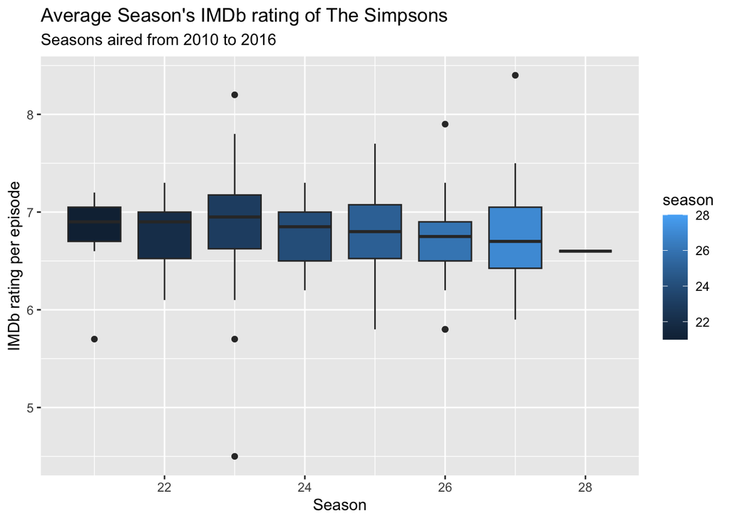

```r
#step a : define the data
simpsons_eps_clean |>
  filter(imdb_rating != "NA") |>
  #step b : define the aesthetic and variables
  ggplot(aes(x = season,
             y = imdb_rating,
             group = season,
             fill = season)) +
  #step c : define what kind of plot you want to make
  geom_boxplot() +
  #step d : define your labels
  labs(x = "Season",
       y ="IMDb rating per episode",
       title = "Average Season's IMDb rating of The Simpsons",
       subtitle = "Seasons aired from 2010 to 2016"
)
```

## b. Scatterplots

Is there a relationship between word count and IMDb rating?

Using `ggplot` and `simpsons_wc_by_season`, we can plot the IMDb ratings of each season related to the total spoken word count of the season to observe any trends:

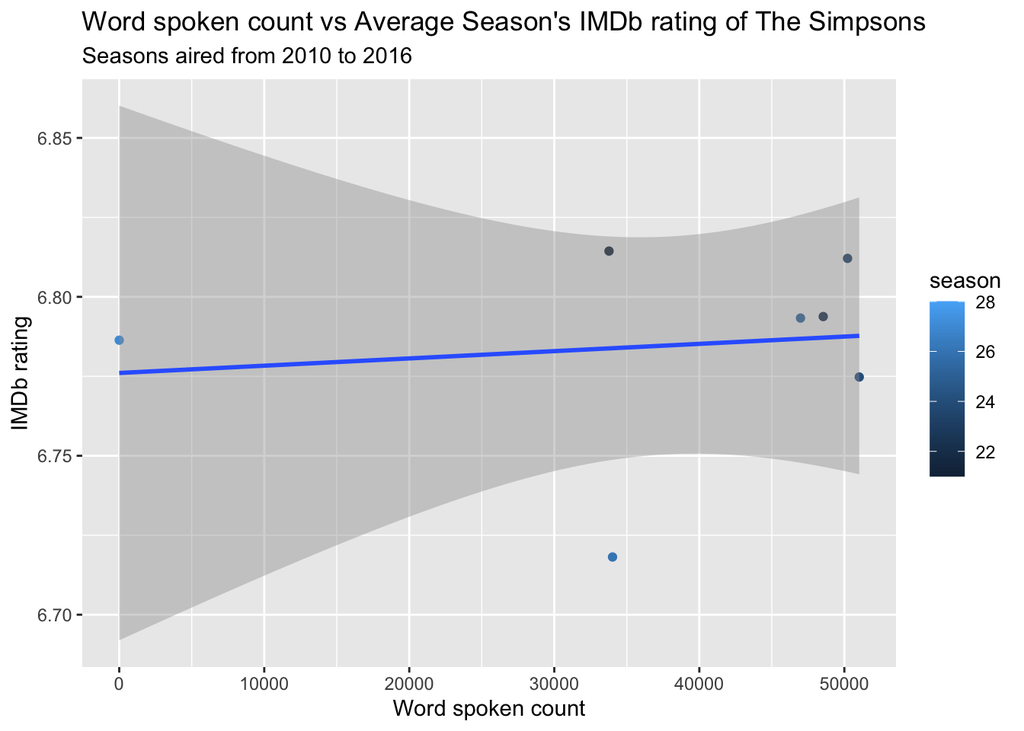

```r
#step a : define the data
simpsons_wc_by_season |>
  #step b : define the aesthetic and variables
  ggplot(
    mapping = aes(x = total_word_count,
                  y = avg_imdb_rating)) +
  #step c : define what kind of plot you want to make
  geom_point(aes(color = season)) +
  geom_smooth(method = "lm") +
  #step d : define your labels
  labs(
    title = "Word spoken count vs Average Season's IMDb rating of The Simpsons",
    subtitle = "Seasons aired from 2010 to 2016",
    x = "Word spoken count",
    y = "IMDb rating"
    )
```

Your turn! Using `simpsons_episodes`, edit the code to plot the relationship between the episode’s original air date `original_air_date` and us viewers `us_viewers_in_million`. Label your plot!

```r
#Edit the code
#step a : define the data
simpsons_episodes |>
  #step b : define the aesthetic and variables
  ggplot(
    mapping = aes(x = ...,
                  y = ...)) +
  #step c : define what kind of plot you want to make
  geom_point(aes(color = season)) +
  geom_smooth(method = "lm") +
  #step d : define your labels
  labs(
    title = "...",
    subtitle = "Seasons aired from 2010 to 2016",
    x = "...",
    y = "..."
```

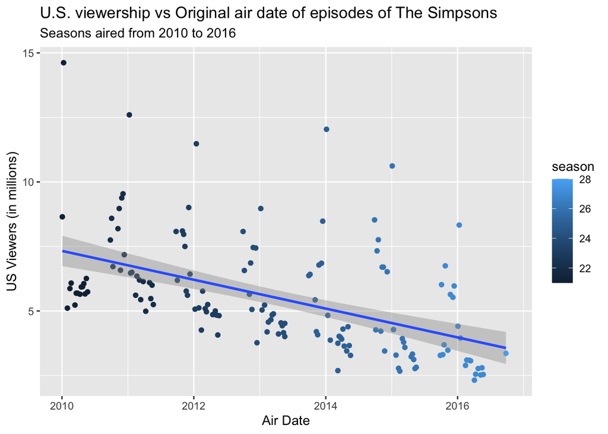

```r
#Solution
#step a : define the data
simpsons_episodes |>
  #step b : define the aesthetic and variables
  ggplot(
    mapping = aes(x = original_air_date,
                  y = us_viewers_in_millions)) +
  #step c : define what kind of plot you want to make
  geom_point(aes(color = season)) +
  geom_smooth(method = "lm") +
  #step d : define your labels
  labs(
    title = "U.S. viewership vs Original air date of episodes of The Simpsons",
    subtitle = "Seasons aired from 2010 to 2016",
    x = "Air Date",
    y = "US Viewers (in millions)"
    )
```

The median IMDb season rating isn’t the only thing that decreased over the year and seasons for the show: so did U.S. viewership.  
Each season has an episode with a high outlying number of viewers in the U.S. but overall, we can see there is a moderate negative linear relationship between an episode’s U.S. viewership and its original air date.

## c. Bar chart

Remember when we filtered the `simpsons_characters` by gender?  
If we wanted to create a bar chart of the gender variable to observe the gender distribution, we would use `geom_bar()`.  
*It’s best to filter out characters with unreported gender here!*

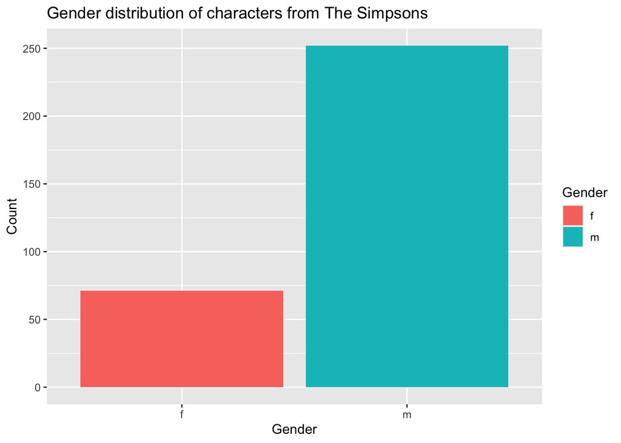

```r
#step a : define the data
simpsons_characters |>
  filter(gender != "NA") |> #filter out characters with undefined genders
  #step b : define the aesthetic and variables
  ggplot(
    aes(x = (gender),
        fill = gender)
    ) +
  #step c : define what kind of plot you want to make
  geom_bar() +
  #step d : define your labels
  labs(
    title = "Gender distribution of characters from The Simpsons",
    x = "Gender",
    y = "Count",
    fill = "Gender"
    )
```

The plot shows us that the majority of characters from the Simpsons are male. There are at least three times as many male characters as there are female characters.

# Conclusion

Congratulations! You learned how to D’ohta wrangle!